# DSS Customers By Year - Unique ID Report

## SUMMARY OF DATA ELEMENT

Unique ID is DSS’s unique identifier. Each value represents a DSS customer. In the DSS Customers dataset, customers can be represented by multiple rows which each summarize the DSS services received by that customer in a given year.  
**Number of Unique Values:**

| Permissible values are those of 7 digits in length |
| --- |

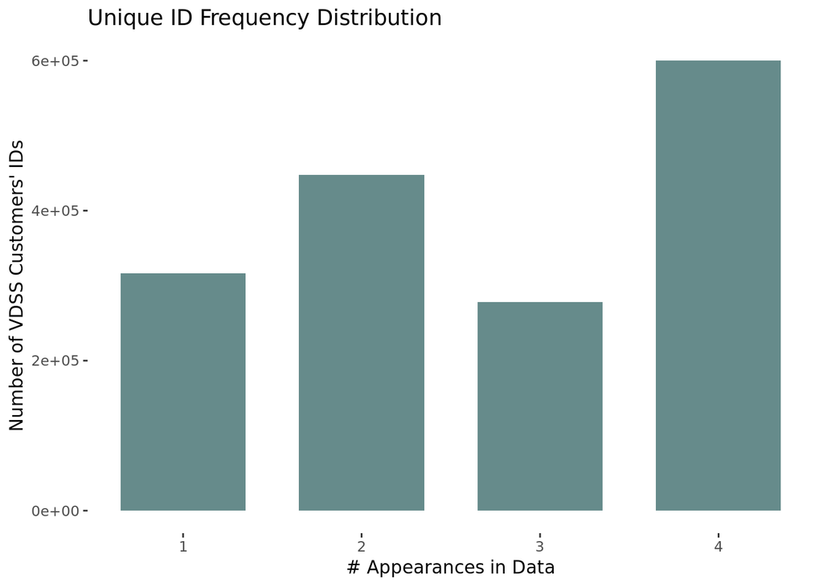

## DATA ANALYTICS SUMMARY OF RESULTS

| Test | Measurementvalues | Value |
| --- | --- | --- |
| Completeness | Number of missing values | 0 |
|  | Percent of complete values | 100 % |
| Validity | Number of invalid values | 0 |
|  | Percent of valid values | 100 % |
| Uniqueness | Number of unique values | 1642365 |
| Longitudinal Inconsistency I | Individuals with inconsistent records | 133 |
|  | Percent individuals with consistent records | 99.99 % |
| Longitudinal Inconsistency II | Individuals with inconsistent records | 232597 |
|  | Percent individuals with consistent records | 85.83 % |

## UNIQUENESS

### A frequency distribution of values for Unique ID .

A basic Unique ID distribution plot is shown giving the frequency of the values Permissible values are those of 7 digits in length occuring in the dataset.  
**Number of unique values 1642365**

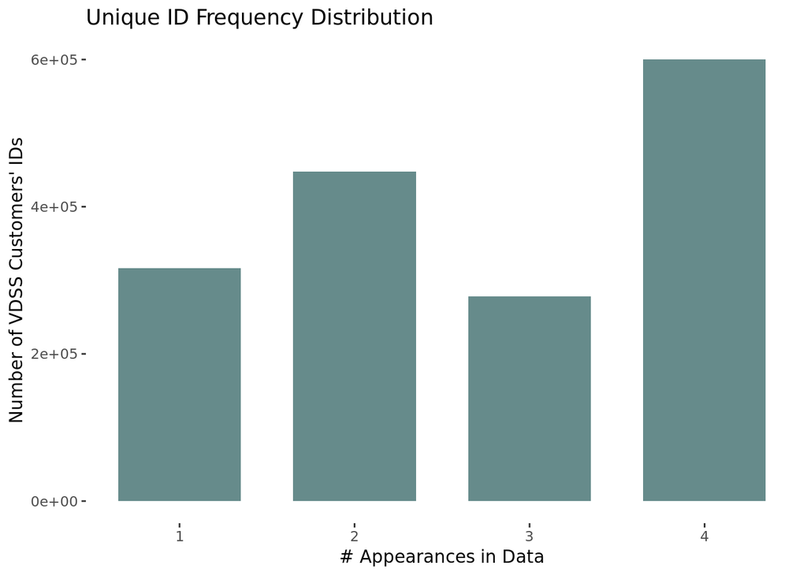

```r
# find non-blank rows
values <-  cust_by_yr[!is_blank(unique_id), .(unique_id)]
# count unique values
unique_values <- nrow(unique(values))
# frequency distribution table of unique id's
frequencies = as.data.frame(table(values))

# frequency distribution plot of active_status values
ggplot(frequencies, aes(Freq)) +
  geom_bar(fill ="paleturquoise4", width=.7) +
  ggtitle(paste(column_name_print, "Frequency Distribution")) +
  xlab("# Appearances in Data") +
  ylab("Number of VDSS Customers' IDs") +
  theme(panel.background=element_blank())
```

```r
kableExtra::kable_styling(knitr::kable(head(frequencies)), stripe_color = "grey!6")
```

| values | Freq |
| --- | --- |
| 2222AQQ | 4 |
| 2222QQQ | 2 |
| 2223AQQ | 1 |
| 2223QQQ | 2 |
| 2224AQQ | 1 |
| 2224QQQ | 2 |

## COMPLETENESS

### Find records with missing values for Unique ID .

The completeness of the data simply refers to whether or not there are missing or NULL values. Whether or not the values should be missing or null is genrally determined when assessing record consistency. In the case of Unique ID there should be no missing values.  
**Number Missing 0**  
**Percent Complete 100 %**

```r
#count missing rows
missing <- cust_by_yr[is_blank(unique_id), .N]
#calculate the percent of the variable which is complete
percent_complete <- truncate(((total_record_count - missing)/total_record_count)*100, prec = 2)

#table missing rows, total rows, percent complete
kableExtra::kable_styling(knitr::kable(
  tibble::tibble("Measure" = c("Missing", "Total Record #", "Percent Complete"),
               "Value" = c(missing, total_record_count, percent_complete))
  ))
```

| Measure | Value |
| --- | --- |
| Missing | 0 |
| Total Record # | 4447018 |
| Percent Complete | 100 |

## VALUE VALIDITY

### Find records with invalid values for Unique ID .

Value validity checks that every value within the dataset is one of the allowed values. In the case of Unique ID all values should be one of the following: Permissible values are those of 7 digits in length  
**Number Invalid: 0**  
**Percent Valid: 100 %**

```r
# get invalid values (values longer/shorter than 7 characters)
invalid = cust_by_yr[is_blank(unique_id)|nchar(unique_id) != 7, .N]
# calculate the percent of the variable which is valid
percent_valid = truncate(((total_record_count - invalid)/total_record_count)*100, prec = 2)

#table invalid rows, total rows, percent complete
kableExtra::kable_styling(knitr::kable(
  tibble::tibble("Measure" = c("Invalid", "Total Record #", "Percent Valid"),
               "Value" = c(invalid, total_record_count, percent_valid)) ))
```

| Measure | Value |
| --- | --- |
| Invalid | 0 |
| Total Record # | 4447018 |
| Percent Valid | 100 |

```r
#conditionally print details of invalid rows
if (invalid > 0){
# get record details
  invalid_details <-
    cust_by_yr[is_blank(unique_id)|nchar(unique_id) != 7, c("unique_id", "calender_year_number", "year_of_birth")]
 knitr::kable(invalid_details)
}
```

## LONGITUDINAL CONSISTENCY I

### An inconsistency in the data is checked over time (longitudinal), to see if the same value is recorded for every new record. For Unique ID this would be if a student recorded as one Unique ID one year but another Unique ID the next year. .

**Individuals with Inconsistent Records: 133**  
**Percent Consistent: 99.99 %**

```r
# Do any customers/unique IDs have more than 1 birth year?

# find & count unique IDs with more than 1 birth year
longitudinal_inconsistent_1 <- cust_by_yr[, .N, by = .(unique_id, year_of_birth)][, .N, by = unique_id][N > 1, .(unique_id)]
longitudinal_inconsistent_count_1 <- nrow(longitudinal_inconsistent_1)

# calculate percentage of unique IDs with 1 birth year
longitudinal_percent_consistent_1 <-
  truncate(((total_person_count - longitudinal_inconsistent_count_1)/total_person_count)*100, prec = 2)

# table # Inconsistent IDs (ids with more than 1 birth year), # total persons, percentage consistent
kableExtra::kable_styling(knitr::kable(
  tibble::tibble(
    "Measure" = c("# Inconsistent IDs", "Total Person Count", "Percent Consistent"),
    "Value" = c(longitudinal_inconsistent_count_1, total_person_count, longitudinal_percent_consistent_1)) ))
```

| Measure | Value |
| --- | --- |
| # Inconsistent IDs | 133.00 |
| Total Person Count | 1642365.00 |
| Percent Consistent | 99.99 |

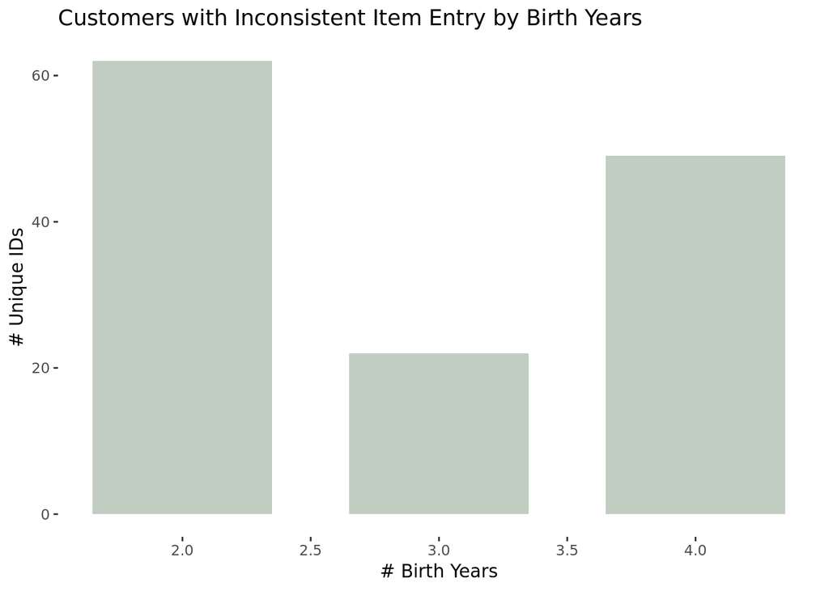

```r
# get record details
longitudinal_inconsistent_1_details <- cust_by_yr[unique_id %in% longitudinal_inconsistent_1$unique_id, .(unique_id, year_of_birth)]

# read in data
year_plot_df <-
  as.data.frame(
    table(longitudinal_inconsistent_1_details[[1]]))

# plot inconsistencies by Birth Year
birth_year <- (ggplot(
  year_plot_df, aes(Freq)) +
  geom_bar(fill ="honeydew3", width=.7) +
  ggtitle("Customers with Inconsistent Item Entry by Birth Years") +
  xlab("# Birth Years") +
  ylab("# Unique IDs") +
  theme(panel.background=element_blank()))

print(birth_year)
```

## LONGITUDINAL CONSISTENCY II

### An inconsistency in the data is checked over time (longitudinal), to see if the same value is recorded for every new record. For Unique ID this would be if a student recorded as one Unique ID one year but another Unique ID the next year. .

**Number Inconsistent: 232597**  
**Percent Consistent: 85.83 %**

```r
# Do any customers/unique IDs have more than 1 county FIPS code?

# pull in SNAP for county FIPS code
snap <- data.table::fread("~/git/vecf_counts/data/original/q4/DSS/DSS SNAP Customers by Year.csv",
                          colClasses = "character")
colnames(snap) <- standard_col_names(colnames(snap))

# set join keys in DSS customers and SNAP
setkey(snap, unique_id)
setkey(snap, study_group_id)
setkey(snap, calendar_year_number)
setkey(cust_by_yr, unique_id)
setkey(cust_by_yr, study_group_id)
setkey(cust_by_yr, calender_year_number)

# join the data
cust_by_yr_snap <- cust_by_yr[snap, nomatch = 0, on = c("unique_id", "study_group_id", "calender_year_number" = "calendar_year_number")]

# find and count unique IDs with more than one county FIPS code
longitudinal_inconsistent_2 <- cust_by_yr_snap[, .N, by = .(unique_id, county_fips_code)][, .N, by = unique_id][N>1, .(unique_id)]
longitudinal_inconsistent_count_2 <- nrow(longitudinal_inconsistent_2)

#calculate percent unique IDs with only one county FIPS code
longitudinal_percent_consistent_2 <-
  truncate(((total_person_count - longitudinal_inconsistent_count_2)/total_person_count)*100, prec = 2)

kableExtra::kable_styling(knitr::kable(
  tibble::tibble(
    "Measure" = c("# Inconsistent IDs", "Total Person Count", "Percent Consistent"),
    "Value" = c(longitudinal_inconsistent_count_2, total_person_count, longitudinal_percent_consistent_2)) ))
```

| Measure | Value |
| --- | --- |
| # Inconsistent IDs | 232597.00 |
| Total Person Count | 1642365.00 |
| Percent Consistent | 85.83 |

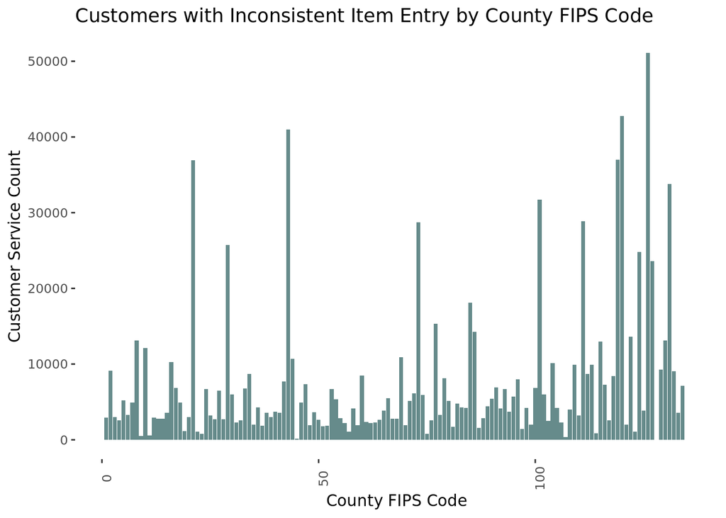

```r
# get record details
longitudinal_inconsistent_2_details <- cust_by_yr_snap[cust_by_yr_snap$unique_id %in% longitudinal_inconsistent_2$unique_id, .(unique_id, county_fips_code, zip_code)]

# read in data
year_plot_df <-
  as.data.frame(
    table(longitudinal_inconsistent_2_details[[3]], longitudinal_inconsistent_2_details[[2]]))

#plot inconsistencies by FIPS code
ggplot(
  year_plot_df, aes((as.numeric(Var2)/10)*10, Freq)) +
  geom_bar(stat="identity", fill = "paleturquoise4") +
  ggtitle("Customers with Inconsistent Item Entry by County FIPS Code") +
  xlab("County FIPS Code") + ylab("Customer Service Count") +
  theme(panel.background=element_blank(), axis.text.x = element_text(angle = 90))
```